# Severe Weather Costs 1950 - 2011

Jeff Anderson

7/24/2018

# SEVERE WEATHER COSTS FROM 1950 TO 2011

The main purpose of this analysis is to total up the human and monetary costs of severe weather from 1950 to 2011. This study will summarize and rank the following measures per event in descending order (most expensive firsts) The following costs are summarized:

- Total Number Injuries (worst 10)
- Total Number of Fatalities (worst 10)
- The Sum of Crop and Property Damage in Billions (worst 10)

## DATA

The source of this data is the NOAA Storm Database

## Load Data

If the data does not exist in the folder download and unzip it. Then, regardless load all the data

```r
library(dplyr)
library(lubridate)
```

```r
library(ggplot2)
library(R.utils)
if (!file.exists("StormData.csv")) {
  download.file("https://d396qusza40orc.cloudfront.net/repdata%2Fdata%2FStormData.csv.bz2","StormData.csv.bz2")
  bunzip2("StormData.csv.bz2")
}

raw.data = read.table("StormData.csv", sep=",", header = T, stringsAsFactors = F)

# list column headings
print(colnames(raw.data))
```

```
##  [1] "STATE__"    "BGN_DATE"   "BGN_TIME"   "TIME_ZONE"  "COUNTY"
##  [6] "COUNTYNAME" "STATE"      "EVTYPE"     "BGN_RANGE"  "BGN_AZI"
## [11] "BGN_LOCATI" "END_DATE"   "END_TIME"   "COUNTY_END" "COUNTYENDN"
## [16] "END_RANGE"  "END_AZI"    "END_LOCATI" "LENGTH"     "WIDTH"
## [21] "F"          "MAG"        "FATALITIES" "INJURIES"   "PROPDMG"
## [26] "PROPDMGEXP" "CROPDMG"    "CROPDMGEXP" "WFO"        "STATEOFFIC"
## [31] "ZONENAMES"  "LATITUDE"   "LONGITUDE"  "LATITUDE_E" "LONGITUDE_"
## [36] "REMARKS"    "REFNUM"
```

```r
# get table structure
print(str(raw.data))
```

```
## 'data.frame':    902297 obs. of  37 variables:
##  $ STATE__   : num  1 1 1 1 1 1 1 1 1 1 ...
##  $ BGN_DATE  : chr  "4/18/1950 0:00:00" "4/18/1950 0:00:00" "2/20/1951 0:00:00" "6/8/1951 0:00:00" ...
##  $ BGN_TIME  : chr  "0130" "0145" "1600" "0900" ...
##  $ TIME_ZONE : chr  "CST" "CST" "CST" "CST" ...
##  $ COUNTY    : num  97 3 57 89 43 77 9 123 125 57 ...
##  $ COUNTYNAME: chr  "MOBILE" "BALDWIN" "FAYETTE" "MADISON" ...
##  $ STATE     : chr  "AL" "AL" "AL" "AL" ...
##  $ EVTYPE    : chr  "TORNADO" "TORNADO" "TORNADO" "TORNADO" ...
##  $ BGN_RANGE : num  0 0 0 0 0 0 0 0 0 0 ...
##  $ BGN_AZI   : chr  "" "" "" "" ...
##  $ BGN_LOCATI: chr  "" "" "" "" ...
##  $ END_DATE  : chr  "" "" "" "" ...
##  $ END_TIME  : chr  "" "" "" "" ...
##  $ COUNTY_END: num  0 0 0 0 0 0 0 0 0 0 ...
```

[output cut: 24 more lines]

## Data Analysis / Transformations

Based on the list of columns I only have interest in date, event, fatality, injury and cost related items where there are amounts > 0

```r
base.data = raw.data %>%
    select(BGN_DATE,EVTYPE,FATALITIES,INJURIES,PROPDMG,PROPDMGEXP,CROPDMG,CROPDMGEXP) %>%
    filter(FATALITIES>0 | INJURIES>0 | PROPDMG>0, CROPDMG>0)
```

Now we need to see the codes used for costs

```r
print(unique(base.data$PROPDMGEXP))
```

```
## [1] "B" "M" "m" "K" "5" ""  "0" "3"
```

```r
print(unique(base.data$CROPDMGEXP))
```

```
## [1] "M" "K" "m" "k" "B" "0" ""
```

Looks like we have some mixed case values, let us fix that:

```r
base.data$PROPDMGEXP = toupper(base.data$PROPDMGEXP)
base.data$CROPDMGEXP = toupper(base.data$CROPDMGEXP)
```

Now let’s see that there are no lower case values..

```r
print(unique(base.data$PROPDMGEXP))
```

```
## [1] "B" "M" "K" "5" ""  "0" "3"
```

```r
print(unique(base.data$CROPDMGEXP))
```

```
## [1] "M" "K" "B" "0" ""
```

Based on the above let’s standardize on Billions. This will require a factor to multiply the costs by to convert all costs to Billions (factors above). From there we calculate total costs in billions by multiplying crop and property costs by each factor and adding the two products to get total cost.

```r
base.data = base.data %>%
  mutate(prop.factor = ifelse(PROPDMGEXP == "B", 1,
                         ifelse(PROPDMGEXP=="M", .001,
                            ifelse(PROPDMGEXP=="K", .000001,0)))) %>%
  mutate(crop.factor = ifelse(CROPDMGEXP == "B", 1,
                          ifelse(CROPDMGEXP=="M", .001,
                            ifelse(CROPDMGEXP=="K", .000001,0)))) %>%
  mutate(total.cost = (PROPDMG * prop.factor) + (CROPDMG * crop.factor))

print(head(base.data))
```

```
##            BGN_DATE                    EVTYPE FATALITIES INJURIES PROPDMG
## 1 10/4/1995 0:00:00 HURRICANE OPAL/HIGH WINDS          2        0     0.1
## 2 6/26/1994 0:00:00        THUNDERSTORM WINDS          0        0     5.0
## 3  8/3/1995 0:00:00            HURRICANE ERIN          0        0    25.0
## 4 10/3/1995 0:00:00            HURRICANE OPAL          0        0    48.0
## 5 10/4/1995 0:00:00            HURRICANE OPAL          0        0    20.0
## 6 3/24/1994 0:00:00        THUNDERSTORM WINDS          0        0    50.0
##   PROPDMGEXP CROPDMG CROPDMGEXP prop.factor crop.factor total.cost
## 1          B      10          M       1e+00       1e-03     0.1100
## 2          M     500          K       1e-03       1e-06     0.0055
## 3          M       1          M       1e-03       1e-03     0.0260
## 4          M       4          M       1e-03       1e-03     0.0520
## 5          M      10          M       1e-03       1e-03     0.0300
## 6          K      50          K       1e-06       1e-06     0.0001
```

Now let us look at the different weather events

```r
print(unique(base.data$EVTYPE))
```

```
##  [1] "HURRICANE OPAL/HIGH WINDS"     "THUNDERSTORM WINDS"
##  [3] "HURRICANE ERIN"                "HURRICANE OPAL"
##  [5] "TORNADO"                       "THUNDERSTORM WINDS/HAIL"
##  [7] "FLASH FLOOD"                   "FLASH FLOODING"
##  [9] "THUNDERSTORM WINDS HAIL"       "FLOODING"
## [11] "HEAVY RAIN"                    "HIGH WINDS HEAVY RAINS"
## [13] "FLOOD"                         "THUNDERSTORM WIND"
## [15] "RIVER FLOOD"                   "HAIL"
## [17] "WINTER STORM"                  "HIGH WINDS"
## [19] "WINTER STORM HIGH WINDS"       "WINTER STORMS"
## [21] "SEVERE THUNDERSTORMS"          "SEVERE THUNDERSTORM WINDS"
## [23] "THUNDERSTORMS"                 "FLOOD/FLASH FLOOD"
## [25] "LIGHTNING"                     "HEAVY SNOW"
## [27] "TORNADOES, TSTM WIND, HAIL"    "TROPICAL STORM"
## [29] "TROPICAL STORM GORDON"         "TROPICAL STORM JERRY"
```

[output cut: 34 more lines]

Based on this list it looks like several weather events could be combined

```r
# organaize hurricanes
cur.type = grepl("hurricane", base.data$EVTYPE, ignore.case = T)
base.data[cur.type,2] = "HURRICANE"
# organaize thunderstorm
cur.type = grepl("thunderstorm", base.data$EVTYPE, ignore.case = T)
base.data[cur.type,2] = "THUNDERSTORM"
# organaize flooding
cur.type = grepl("flood", base.data$EVTYPE, ignore.case = T)
base.data[cur.type,2] = "FLOOD"
# organaize flooding
cur.type = grepl("tornado", base.data$EVTYPE, ignore.case = T)
base.data[cur.type,2] = "TORNADO"
#organaize heat
cur.type = grepl("heat", base.data$EVTYPE, ignore.case = T)
base.data[cur.type,2] = "HEAT"
#combine winters storms/blizzards
cur.type = grepl("blizz", base.data$EVTYPE, ignore.case = T)
base.data[cur.type,2] = "WINTER STORM"
cur.type = grepl("winter storm", base.data$EVTYPE, ignore.case = T)
base.data[cur.type,2] = "WINTER STORM"
# assuming tstm = tropical storm
cur.type = grepl("tstm win", base.data$EVTYPE, ignore.case = T)
base.data[cur.type,2] = "TROPICAL STORM"
```

Now let us look at the updated list of events

```r
print(unique(base.data$EVTYPE))
```

```
##  [1] "HURRICANE"              "THUNDERSTORM"
##  [3] "TORNADO"                "FLOOD"
##  [5] "HEAVY RAIN"             "HIGH WINDS HEAVY RAINS"
##  [7] "HAIL"                   "WINTER STORM"
##  [9] "HIGH WINDS"             "LIGHTNING"
## [11] "HEAVY SNOW"             "TROPICAL STORM"
## [13] "TROPICAL STORM GORDON"  "TROPICAL STORM JERRY"
## [15] "HEAT"                   "GLAZE ICE"
## [17] "GUSTNADO"               "WIND DAMAGE"
## [19] "HIGH WIND"              "SNOW"
## [21] "HAIL/WINDS"             "HAIL/WIND"
## [23] "FREEZE"                 "HEAVY RAINS"
## [25] "ICE STORM"              "DUST STORM/HIGH WINDS"
## [27] "FOREST FIRES"           "HAIL 100"
## [29] "THUDERSTORM WINDS"      "DROUGHT"
## [31] "WINDS"                  "HIGH WINDS/COLD"
## [33] "WILD/FOREST FIRE"       "TROPICAL STORM DEAN"
## [35] "WILD/FOREST FIRES"      "WILDFIRES"
## [37] "URBAN/SML STREAM FLD"   "Heavy Rain/High Surf"
## [39] "Extreme Cold"           "STORM SURGE"
## [41] "Frost/Freeze"           "EXTREME COLD"
## [43] "TYPHOON"                "SMALL HAIL"
## [45] "GUSTY WINDS"            "DUST STORM"
## [47] "DRY MICROBURST"         "WILDFIRE"
## [49] "STRONG WIND"            "LANDSLIDE"
## [51] "FROST/FREEZE"           "STORM SURGE/TIDE"
## [53] "TSUNAMI"
```

## Summarize Final Dataset and Subsets

```r
sum.data = base.data %>%
  select(EVTYPE,FATALITIES,INJURIES,total.cost) %>%
  group_by(EVTYPE) %>%
  summarise(TOTAL_FATALITIES = sum(FATALITIES),
            TOTAL_INJURIES = sum(INJURIES),
            TOTAL_COST_BILLIONS = sum(total.cost))

print(head(sum.data))
```

```
## # A tibble: 6 x 4
##   EVTYPE                TOTAL_FATALITIES TOTAL_INJURIES TOTAL_COST_BILLIONS
##   <chr>                            <dbl>          <dbl>               <dbl>
## 1 DROUGHT                              0              4            1.46
## 2 DRY MICROBURST                       0              0            0.000123
## 3 DUST STORM                           0             30            0.00239
## 4 DUST STORM/HIGH WINDS                0              0            0.00055
## 5 Extreme Cold                         1              0            0.02
## 6 EXTREME COLD                         1              0            0.00461
```

```r
sum.fatalities = sum.data %>%
  select(EVTYPE, TOTAL_FATALITIES) %>%
  arrange(desc(TOTAL_FATALITIES), EVTYPE)

print(head(sum.fatalities))
```

```
## # A tibble: 6 x 2
##   EVTYPE       TOTAL_FATALITIES
##   <chr>                   <dbl>
## 1 FLOOD                     239
## 2 TORNADO                   219
## 3 HEAT                       91
## 4 HURRICANE                  78
## 5 WINTER STORM               34
## 6 TSUNAMI                    32
```

```r
sum.injuries = sum.data %>%
  select(EVTYPE, TOTAL_INJURIES) %>%
  arrange(desc(TOTAL_INJURIES), EVTYPE)

print(head(sum.injuries))
```

```
## # A tibble: 6 x 2
##   EVTYPE         TOTAL_INJURIES
##   <chr>                   <dbl>
## 1 FLOOD                    6699
## 2 TORNADO                  2287
## 3 ICE STORM                1603
## 4 HURRICANE                 931
## 5 HEAT                      886
## 6 TROPICAL STORM            542
```

```r
sum.cost = sum.data %>%
  select(EVTYPE, TOTAL_COST_BILLIONS) %>%
  arrange(desc(TOTAL_COST_BILLIONS), EVTYPE)

print(head(sum.cost))
```

```
## # A tibble: 6 x 2
##   EVTYPE         TOTAL_COST_BILLIONS
##   <chr>                        <dbl>
## 1 FLOOD                       141.
## 2 HURRICANE                    42.5
## 3 ICE STORM                     5.11
## 4 TORNADO                       3.99
## 5 HAIL                          3.84
## 6 TROPICAL STORM                2.45
```

## Summary Graphs

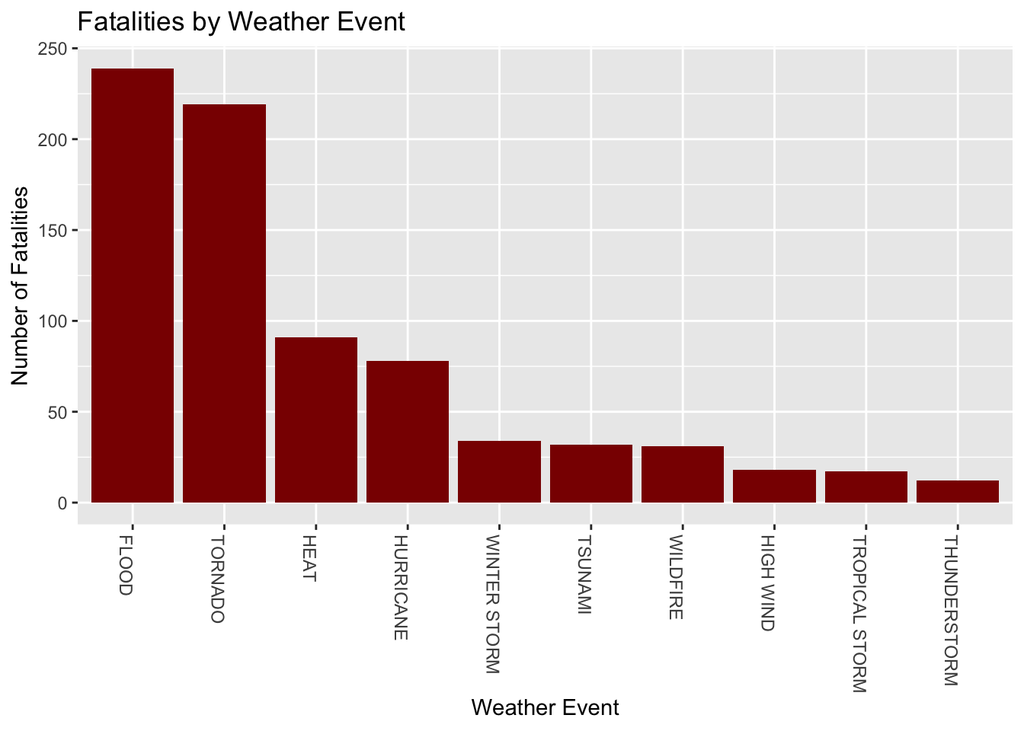

```r
# Total Fatalities Graph
tf = ggplot(data=sum.fatalities[1:10,],
       aes(x=reorder(EVTYPE, -TOTAL_FATALITIES), y=TOTAL_FATALITIES))+
  geom_col(fill="darkred")+
  theme(axis.text.x=element_text(angle = -90, hjust = 0))+
  labs(title="Fatalities by Weather Event", x="Weather Event", y="Number of Fatalities")

print(tf)
```

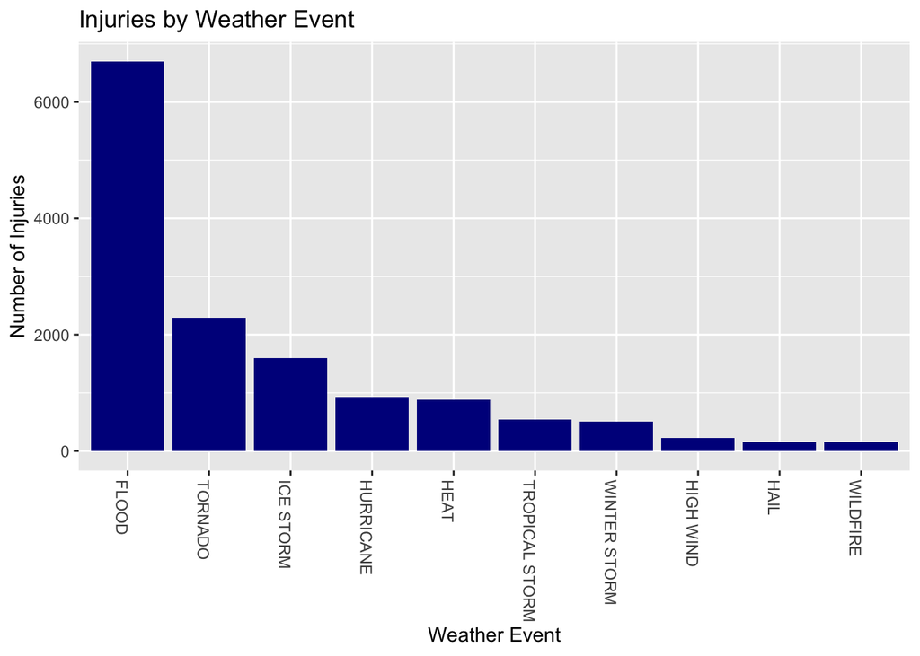

```r
# Total Injuries Graph
ti = ggplot(data=sum.injuries[1:10,],
       aes(x=reorder(EVTYPE, -TOTAL_INJURIES), y=TOTAL_INJURIES))+
  geom_col(fill="darkblue")+
  theme(axis.text.x=element_text(angle = -90, hjust = 0))+
  labs(title="Injuries by Weather Event", x="Weather Event", y="Number of Injuries")

print(ti)
```

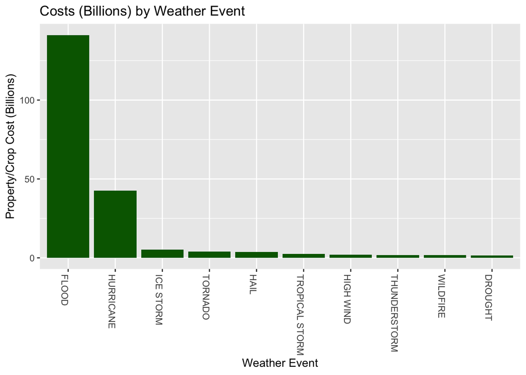

```r
# Total Cost Graph
tc = ggplot(data=sum.cost[1:10,],
       aes(x=reorder(EVTYPE, -TOTAL_COST_BILLIONS), y=TOTAL_COST_BILLIONS))+
  geom_col(fill="darkgreen")+
  theme(axis.text.x=element_text(angle = -90, hjust = 0))+
  labs(title="Costs (Billions) by Weather Event",
       x="Weather Event",
       y="Property/Crop Cost (Billions)")

print(tc)
```

# Final Summary

Floods are the most costly weather event in all respects. Huricanes, tornadoes, heat and ice storms are all very costly as well.

The RPub document is [here](http://rpubs.com/andersjh/repo_weather_data)